# The ISBA Bulletin

September 2025 - Vol. 32 No. 3

# MESSAGE FROM THE PRESIDENT

Michele Guindani

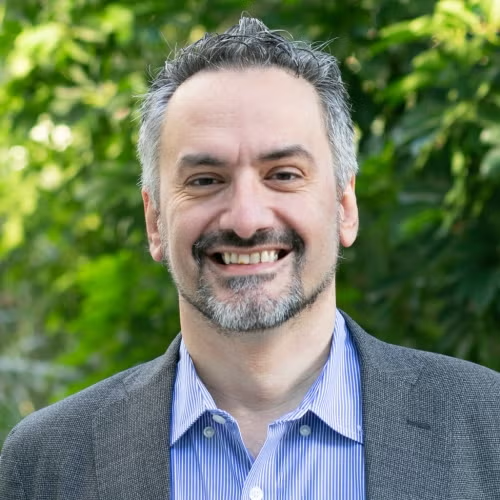

### “Who even reads the ISBA Bulletin?”

One late afternoon in early September, after a conference in Padova (Italy), I sat at a coffee shop with our Bulletin editor, Francesco Denti, and other conference attendees, a mix of young and senior researchers. In the middle of a casual conversation, one of the young researchers asked us, out of the blue and in a bluntly funny way, this precise question. It’s a good question, and one we’ve been considering as Francesco has worked to re-energize the Bulletin: what purpose does the Bulletin serve now, and why should it be on anyone’s reading list?

When I sit down to write these notes, I often browse through the [archive](https://bayesian.org/resources/bulletin/) of the past issues of the Bulletin for orientation and inspiration. There’s quite a bit of society memory tucked in those PDFs. The Bulletin began in 1992 as the *ISBA Newsletter*, a stapled, black-and-white document that resembled a departmental flyer more than a professional publication. The first issue, edited by Tom Leonard, introduced ISBA and articulated an outward-looking mission: advance “Bayesian statistics, science and analysis in the natural, biological and social sciences, engineering, industry, medicine, law, government and education, and by the development and interface of inferential and decision making procedures in all areas.” That note was a call to build a community, global from the start, with letters of support arriving from the Americas, Europe, and Asia, and an acting board already in motion.

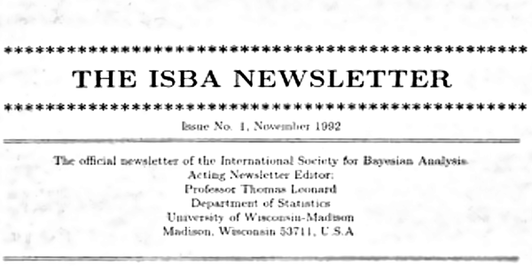

The inaugural ISBA Newsletter (1992), announcing the Society’s mission and providing a first common forum for the community.

Within a year, the Newsletter was reporting on the first ISBA World Meeting (San Francisco, 1993): “nearly 200 participants” squeezed into the Hotel Nikko for invited sessions, a cocktail reception, and dinner.

The same historical recap traces the next early steps, with a meeting in Alicante (1994), which followed a Valencia meeting with 151 official participants, and Cape Town (1996), “with over 100 in attendance.”

Open the [October 1993](https://bayesian.org/wp-content/uploads/2016/09/9310.pdf) issue and you can already see a debate about whether ISBA should start a **journal** “interfacing across disciplines,” with the editor inviting members to write in:

> Most of our members who have discussed this issue believe that a journal would not only be a success, but would also provide substantial motivation for our Society, which would otherwise just end up as an umbrella organization for various Bayesian conferences.

By the late 1990s and early 2000s, the format you recognize today was already in place. An editor became an editorial team with corresponding dedicated associate editors all over the world; regular columns appeared on teaching, software, history, and student activities. ISBA Membership moved from the low hundreds upward, and the Bulletin tracked that growth. If you open the [June 2001](https://bayesian.org/wp-content/uploads/2016/09/0106.pdf) issue, for example, you’ll find a multi-page software review written by Nicky Best, working on a “333 MHz with 96MB Ram laptop”, and a compact survey titled *Bayesians in Ireland*. These pieces were the Bulletin’s way, circa 2000–2005, of mapping the field. They gave members a reliable snapshot of people, topics, and problems; learn who was where, what they were modeling, and how collaborations were forming across departments.

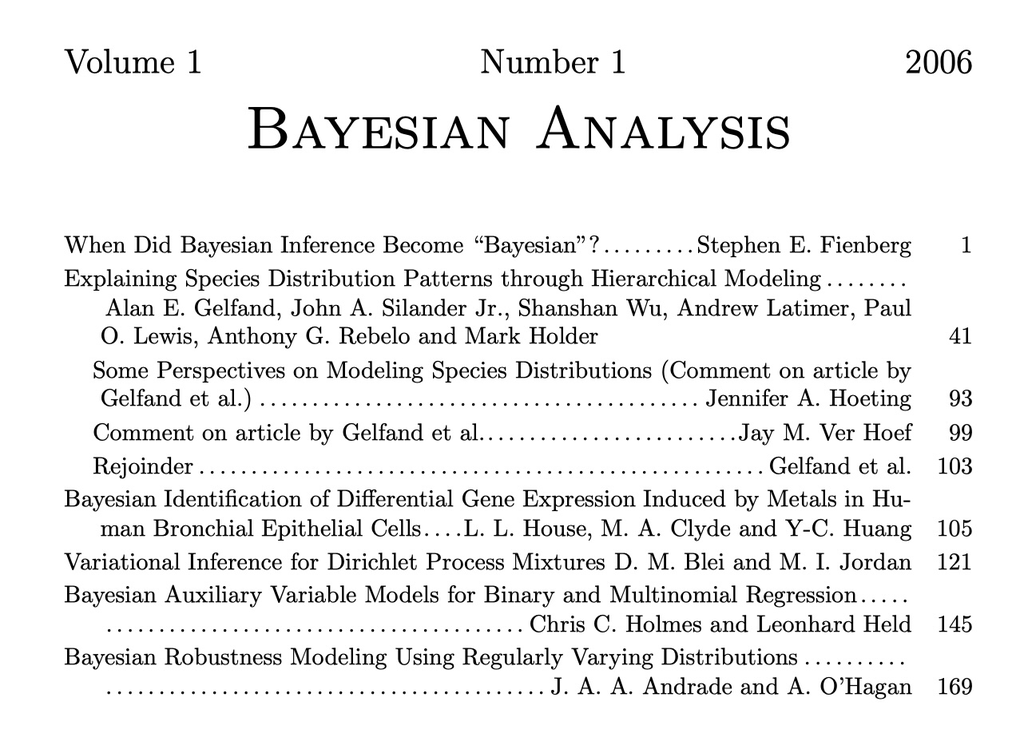

The first issue of the ISBA journal, Bayesian Analysis, edited by Rob Kass.

In the [late 2001](https://bayesian.org/wp-content/uploads/2016/09/0112.pdf) the “journal question” reappears, this time, complete with a concrete proposal for what became *Bayesian Analysis*. There was no social media at the time; discussions took place at the Valencia and ISBA world meetings, and then found a further forum in the Bulletin. By [2005](https://bayesian.org/wp-content/uploads/2016/09/0503.pdf), the Bulletin is reporting that the first issue of *Bayesian Analysis* is imminent. In 2006, the journal was launched with [Volume 1, Issue 1 (March)](https://projecteuclid.org/journals/bayesian-analysis/volume-1/issue-1). From that point on, the Bulletin becomes the primary source for members to find pointers to BA articles, calls for discussion papers, and editorial updates.

The 2010s begin with the formalization of **sections**, and the Bulletin is the record of that change. Objective Bayes (2010), Bayesian Nonparametrics (2010), and BayesComp (approved in 2012) utilized these pages to disseminate election information, bylaws, workshop details, and meeting plans. By 2013, the presidential message described a “banner year for sections and chapters,” reflecting how sections had become a primary delivery mechanism for workshops, elections, and engagement, and how the Bulletin stitched those strands together each quarter. By 2018, the Bulletin includes governance updates, such as the adoption of a code of conduct for meetings and outreach activities (at the time, the ISBA@NeurIPS joint workshop). The Bulletin continues to play a role in announcing policies, cross-community initiatives, and expectations for professional conduct.

The [June 2020](https://bayesian.org/wp-content/uploads/2020/06/2006.pdf) issue discusses the **COVID-19 pandemic** directly in the President’s column and records program adjustments, cancellations/deferrals, and the Society’s plan for continuity. The tone is operational: what changes, what stays on track, and how ISBA will deliver the World Meetings and our services to the membership, which is exactly the value of the Bulletin in challenging times.

Fast forward to the present. The scale is larger: membership well exceeds a thousand; sections are multiplying; j-ISBA is driving mentoring and early-career opportunities. World meetings that once had just a few hundred people now host crowds: Venice 2024 drew nearly 850 participants, with dozens of invited sessions and hundreds of posters. The role of the Bulletin is the same. The Bulletin doesn’t just list numbers; it connects our members, announces new initiatives, and explains the choices and rationale behind them.

**So, who reads it?**  
All of us who are interested in our community moving: students scanning for deadlines and awards; practitioners and researchers tracking discussion papers and section activities; educators seeking the latest advances in Bayesian teaching; and whoever needs a single venue to announce, document, and discuss our path. When we cannot meet in person, we meet through the Bulletin. It is where we celebrate contributions and remember those we have lost. What began as a feeble Newsletter in 1992 is now the Society’s working memory, linking subfields, highlighting opportunities, and announcing future initiatives. If you care about where Bayesian statistics is going and how we care for the community, read the Bulletin. It is not just news; it is how we keep record of who we are.

**New ISBA Section! The Bayesian Social Sciences (BSS) Section.**  
I am pleased to share that, very much in the spirit of Tom Leonard’s inaugural ISBA newsletter, the *Bayesian Social Sciences* Section of ISBA has been officially approved. The Section’s purpose is to promote the research, application, and dissemination of Bayesian inference for problems in the social sciences and the humanities. “Social sciences” is interpreted broadly, including but not limited to Anthropology, Archaeology, Demography, Economics, Geography, History, Linguistics, Political Science, Psychology, and Sociology. Inaugural Section officers are: Adrian Raftery (Chair, University of Washington), Robin Ryder (Chair elect, Imperial College London), Nial Friel (Program chair, University College Dublin), Monica Alexander (Treasurer, University of Toronto), Eric Jan Wagenmakers (Secretary, University of Amsterdam). Further information is available on the [BSS Section website](https://bss-isba.github.io).

**Supporting PhD Students from Low-GNI Countries.**  
I am pleased to announce that the Executive Council will soon propose a motion to the Board of Directors to offer free memberships for verified PhD students who reside in [countries](https://data.worldbank.org/indicator/NY.GNP.PCAP.PP.CD) with a low per capita Gross National Income (GNI). We extend our thanks to j-ISBA for championing this important and inclusive change to our membership structure. If approved by the Board, the change will be effective from January 1, 2026.

**Collaboration with sister societies.**  
It is essential that we establish concrete opportunities for collaboration with other statistical societies. Two current touchpoints are SisBayes, the official Bayesian Section of the Italian Statistical Society, and the ASA Section on Bayesian Statistical Science (SBSS). SisBayes held its first post-pandemic conference this year, the first in seven years; we include more details later in the Bulletin. At JSM in Nashville, we shared an exhibitor’s table with SBSS, which provided a practical way for us to work more closely. We expect to build on that foundation in the coming months. If you have suggestions for relationships we should pursue with other societies, please let us know.

**Inside this Bulletin: ISBA awards, activities, deadlines, elections, and more.**  
We celebrate the 2024 Savage Awardees and honorable mentions, and the 2024 Mitchell Prize winner and honorable mentions; full details appear in the *Awards* section. Please see later in this issue for the ISBA Fellows and Zellner Medal calls, which include timelines, eligibility criteria, and submission instructions. In their note, the Program Council announces the call for contributed talks and posters for the ISBA World Meeting in Nagoya (June 28–July 3, 2026); submissions are due by November 21, 2025. A note from Igor Prünster, Editor-in-Chief of *Bayesian Analysis*, highlights current discussion papers, a single venue to access all BA webinars tied to discussion articles (recordings available via the BA page and ISBA’s YouTube), updates on the growth of the journal, and steps to keep Advance Publications moving smoothly. A round-up of meeting reports and approaching deadlines appears in *News from the World*. The elections for new ISBA and Section officers are fast approaching. Please review the slate of candidates, which can be found on the final pages of the Bulletin.

Finally, for one-click access to all things ISBA, sections, YouTube videos, main events, and key resources, you can now visit our [Linktree page](https://linktr.ee/ISBAbayesian). Place a bookmark on your browser!

# FROM THE EDITOR

Francesco Denti

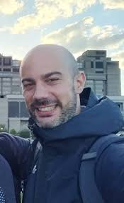

Well, there isn’t much I can add to what Michele Guindani has already expressed in his message as ISBA President. The coffee we had after that conference must have been strong!

Jokes aside, the historical journey of the Bulletin that Michele retraced is truly significant - especially for those of us on the Editorial Board (whom I cannot thank enough for their constant dedication). It reminds us that, as writers and readers alike, we are part of something meaningful: contributing to a resource that matters for the whole Society.

Since the contents of this issue have already been well summarized, I won’t take up any more of your time. ISBA community, enjoy!

# FROM THE PROGRAM COUNCIL

Sameer Deshpande

[figure not shown]

### ISBA 2026 World Meeting

The [2026 ISBA World Meeting](https://isba2026.github.io) is getting closer.  
We are very excited to see you in Nagoya, Japan, from June 28 to July 3, 2026!

**Invited Sessions.** The Scientific Committee received an overwhelming number of high-quality proposals for invited sessions, nearly double the total number of available slots in the program! Decision emails were sent to session organizers in mid-September.  
Thanks to everyone who submitted a session. If your session was not selected, please submit a proposal to give a contributed talk or poster (see below).

**Contributed Talks & Posters.** The Scientific Committee welcomes proposals for contributed talks and posters. Contributed talks will be around 15 minutes long. Please submit proposals using [this form](https://forms.gle/dVTUrdEuVF6gZPj26).  
Proposals received before 11:59pm (Anywhere on Earth) on **November 21, 2025** will be considered for inclusion in the program as a contributed talk or a poster. Decisions will be announced in mid-December 2025.  
Proposals received after November 21, 2025, will be considered for inclusion in the program as a poster on a rolling basis, subject to space availability.

Please note that **one-oral-presentation-per-person policy** is in effect for the meeting: Each participant can give at most **one** oral presentation. All talks (invited or contributed), discussions, panel discussions, and poster presentations count as oral presentations.  
Limited exceptions to this policy may be made at the discretion of the Program Council to accommodate program needs.

**Short Course.** If you are interested in teaching a half-day (i.e., 3-hour) short course at the 2026 ISBA World Meeting, please email the Program Council at program-council@bayesian.org.  
The Short Course is scheduled to run from 10am to 1pm on **Sunday, June 28, 2026**.

**Plenary Speakers.** The 2026 ISBA World Meeting will feature four Foundational and four Keynote Lectures.Foundational Lectures celebrate excellent researchers who have made notable and substantial contributions to the Bayesian community throughout their careers. Keynote Lectures highlight exciting new research developments.

The Scientific Committee is delighted to announce that David Dunson, Hal Stern, Sylvia Richardson, and Siddhartha Chib will deliver the Foundational Lectures and that Fumiyasu Komaki, Botond Szabo, Barbara Engelhardt, and Emtiyaz Khan will deliver the Keynote Lectures.

**Named Lectures**. The Susie Bayarri and Bruno de Finetti Lecturers are major highlights of ISBA World Meetings. The Susie Bayarri Lecture is delivered by an outstanding young researcher and the Bruno de Finetti Lecture is delivered by an outstanding scholar who has provided significant contributions to the advancement of Bayesian Statistics.

The Named Lecture Committee is delighted to announce that Daniele Durante will deliver the Bayarri Lecture and Peter Mueller will deliver the de Finetti Lecture at the 2026 ISBA World Meeting.  
Stéphanie van der Pas will also deliver the re-scheduled 2024 Bayarri Lecture at the meeting in Nagoya.

**Local travel & registration information.** The Local Organizing Committee has posted some local information — including directions to Nagoya and to the venue, a list of accommodation options, and some local attractions — on the [meeting website](https://isba2026.github.io).  
Registration rates will be posted on the meeting website in mid-October 2025, and registration will open in early 2026.

### Endorsement Requests

If you are planning a meeting and would like to request financial (co-)sponsorship or non-financial endorsement from ISBA, please submit your request to the Program Council. Detailed information on how to submit such requests is available [at this link](https://bayesian.org/events/request-sponsorshipendorsement/).

# UPDATES FROM BA

Igor Prünster

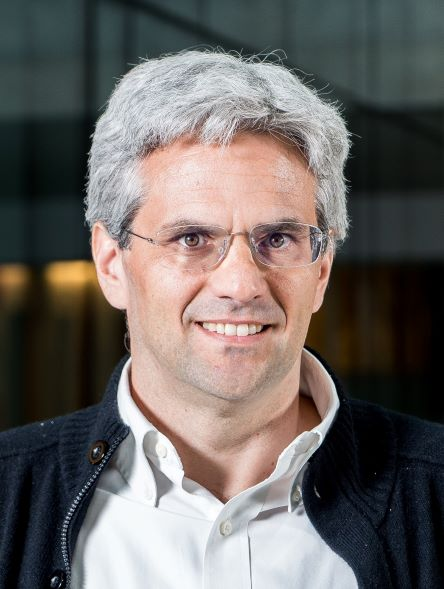

### Editorial Updates

The first nine months of 2025 have seen a substantial increase in submissions to *Bayesian Analysis*, up by about 25% compared to the same period last year. This growth reflects the vitality of our field and the active engagement of the community with the journal as a venue for high-quality Bayesian research. At the current pace, we are on track to well over 300 submissions by the end of the year.

You will also notice that the [September 2025 issue](https://projecteuclid.org/journals/bayesian-analysis/volume-20/issue-3) of *Bayesian Analysis* is somewhat “thicker” than usual. This reflects our decision to reduce the backlog in the [Advance Publication](https://projecteuclid.org/journals/bayesian-analysis/advance-publication) section. While papers published there are final and assigned a DOI, the queue had grown to about 1.5 years, which we felt was too long. To address this, we are increasing the number of articles in each issue until we reach a more balanced equilibrium.

Last but not least, I am very pleased to report that we have met the goals we set ourselves earlier this year in terms of turnaround times and, in particular, in controlling outliers. All papers submitted within the first five months of 2025 have already received a decision, meaning within four months of submission. I want to sincerely thank our Co-Editors, Associate Editors, and referees for their diligence and responsiveness — and for their patience when I chase them for updates. The credit for this achievement is entirely theirs. We will continue to do our best to sustain this momentum, as a timely and consistent editorial process is crucial to attracting the community’s best work. I very much hope this will further encourage researchers to consider *Bayesian Analysis* as the preferred outlet for their top-tier work.

### Discussion Papers

In mid-September, we hosted the webinar for the discussion paper  
[A Tree Perspective on Stick-Breaking Models in Covariate-Dependent Mixtures](https://doi.org/10.1214/24-BA1462)  
by A. Horiguchi, C. Chan, and L. Ma. The invited discussions by S. MacEachern, A. Rodriguez, D. Dahl, and G. Page, as well as those by B. Franzolini and G. Rebaudo, together with many stimulating contributed discussions, provided a rich set of complementary perspectives, ranging from theoretical insights into covariate-dependent nonparametric models to practical considerations for computation and applications. I am grateful to the authors, discussants, and all participants for making this a great success.

We now look forward to the webinar for our next discussion paper,  
[Model Uncertainty and Missing Data: An Objective Bayesian Perspective](https://doi.org/10.1214/25-BA1531)  
by G. García-Donato, M.E. Castellanos, S. Cabras, A. Quirós, and A. Forte.  
It will take place on *November 5, 2025, at 4:00pm UTC*,  
with invited discussions by M. Clyde, M. Ferreira, A. Ly, and J. Rubio.  
I warmly encourage you to join us.

### Online Resources

I would like to sincerely thank Julyan Arbel and the whole ISBA Media Team for the outstanding work they are doing behind the scenes to ensure the smooth running of the webinars. In addition, they have created a dedicated webpage gathering all BA webinars since 2019:

https://bayesian.org/ba-webinars/

This page brings together a remarkable collection of talks that span the full breadth of Bayesian statistics.

Beyond the webinars, the team has also reorganized the [ISBA YouTube channel](https://www.youtube.com/c/ISBAInternationalSocietyofBayesianAnalysis), which now features curated playlists from ISBA World Meetings (2012–2024), specialized workshops and seminars, and content from ISBA Sections (j-ISBA, BNP, BioPharma, Industrial). These resources deserve broad visibility, and I encourage you to explore them, share them with colleagues and students, and provide feedback to Julyan (julyan.arbel@inria.fr).

# AWARDS

Surya Tokdar and Lucia Paci

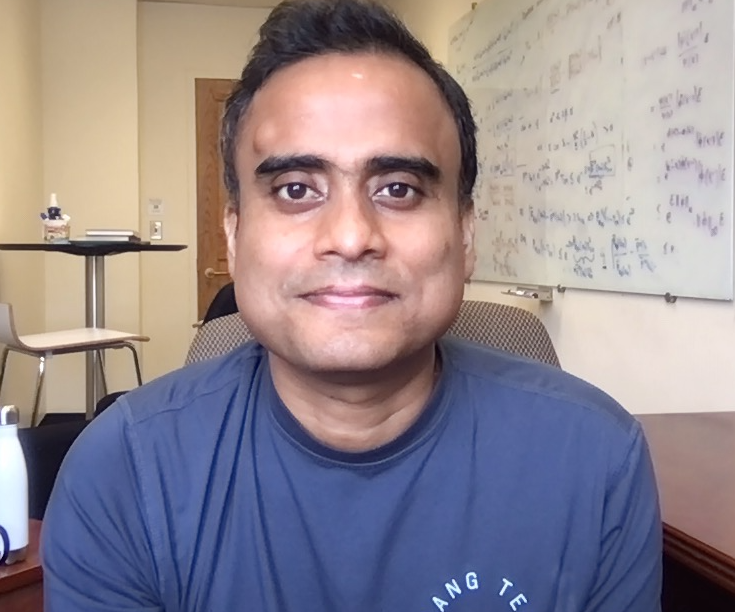

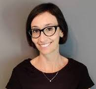

## Savage Applied Methodology 2024

**Awards Committee:**  
Veronica Berrocal (Chair; UC Irvine, USA);  
Roberta De Vito (Brown University, USA);  
Dani Gamerman (UFRJ, Brazil);  
Clara Grazian (University of Sydney, Australia);  
Andrew Holbrook (UCLA, USA);  
Juhee Lee (UC Santa Cruz, USA);  
Andrew Zammit-Mangion (University of Wollogong, Australia).

**Honorable Mentions:**

**Nicholas Marco**, PhD at UCLA; *“Mixed Membership Models with Applications to Neuroimaging.”*

**Melodie Monod**, PhD at Imperial College London; *“Bayesian Models and Methods to Estimate Age-specific Infectious Disease Transmission Dynamics.”*

**Winner:**

**Alessandro Zito**, PhD at Duke University; *“Ecological Modeling via Bayesian Nonparametric Species Sampling Priors.”*

## Savage Theory and Methods 2024

**Awards Committee:**  
Marta Catalano (Luiss University);  
Peter Hoff (Duke University);  
Jaeyong Lee (Chair; Seoul National University);  
Kyungjae Lee (Sungkyunkwan University);  
Feng Liang (University of Illinois Urbana–Champaign);  
Depdeep Pati (University of Wisconsin);  
Yanxun Xu (Johns Hopkins University).

**Honorable Mention:**

**Maria Fernanda Gil-Leyva**, PhD at National Autonomous University of Mexico; *“Stick-breaking Processes and Related Random Probability Measures.”*

**Winner:**

**Takuo Matsubara**, PhD at Newcastle University; *“Bridging the Gap Between Modeling and Computation in Bayesian Statistics.”*

## Mitchell Prize 2024

**Awards Committee:**  
Chris Drovandi (Queensland University of Technology, Australia);  
Didong Li (University of North Carolina, USA);  
Finn Lindgren (University of Edinburgh, UK);  
Brian Reich (Chair; North Carolina State University, USA);  
Toryn Schafer (Texas A&M University, USA).

**Honorable Mentions:**

- Ethan M. Alt, Xiuya Chang, Xun Jiang, Qing Liu, May Mo, Hong Amy Xia, and Joseph G. Ibrahim (2024).  
  “LEAP: The Latent Exchangeability Prior for Borrowing Information from Historical Data.”  
  *Biometrics*, 80(3): 1–10.
- Georgia Papadogeorgou, Carolina Bello, Otso Ovaskainen, and David B. Dunson (2023).  
  “Covariate-Informed Latent Interaction Models: Addressing Geographic & Taxonomic Bias in Predicting Bird–Plant Interactions.”  
  *Journal of the American Statistical Association*, 118(544): 2250–2261.

**Winner:**

- Clara Hoffmann and Nadja Klein (2023).  
  “Marginally Calibrated Response Distributions for End-to-End Learning in Autonomous Driving.”  
  *Annals of Applied Statistics*, 17(2): 1740–1763.

## Calls for nominations

#### New ISBA Fellows

Nominations are now being accepted for **new ISBA Fellows**. Nominees must be current ISBA members and should have been members for the last three consecutive years, at least.

The individual’s contributions should have had a significant impact in promoting Bayesian ideas and methods in society, through scientific works and other activities, such as teaching, consulting or service. Submissions and supporting letters should not be made by current members of the Fellows Selection Committee to avoid conflicts of interest. Nominations may be made by any current ISBA member.

Please prepare nominations as a single PDF file following the convention `LASTNAME_FIRSTNAME.pdf` so the file name corresponds to the nominee, and then email them to fellows@bayesian.org.  
Nominations must be received on or before **February 1, 2026**. The new fellows will be announced at the 2026 ISBA World Meeting in Nagoya, Japan. Please contact Michele Guindani (micheleguindani@gmail.com), ISBA President, with any questions. Questions will be relayed to the ISBA Fellows Committee.

#### ISBA Zellner Medal

Nominations are now being accepted for the **ISBA Zellner Medal**, which recognizes ISBA members who have rendered exceptional and distinguished service to ISBA over an extended period of time, and whose contributions have had an impact on the society beyond the time of his or her incumbency. Nominees must be current ISBA members and should have been members for the last three consecutive years, at least. They should have served ISBA in a range of leadership roles over an extended period of time.

Please prepare nominations as a single PDF file following the convention `LASTNAME_FIRSTNAME.pdf` so the file name corresponds to the nominee and then email them to zellner-medal@bayesian.org. Nominations must be received on or before **January 1, 2026**. The Zellner Medal recipient(s) will be announced and celebrated at the 2026 ISBA World Meeting in Nagoya, Japan.

Please contact Alan Gelfand (alan@duke.edu), Chair of the Zellner Medal Selection Committee, with any questions.

# JUNIOR ISBA

Matteo Giordano

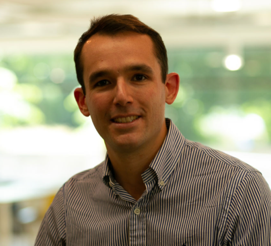

Dear ISBA community,  
On behalf of the j-ISBA Board, let me say that it was wonderful to meet so many of you at the social event we organized during the BNP in Los Angeles, where more than 100 of you attended!

Looking forward, we’re excited to share updates on upcoming events and opportunities that continue to unite our early-career researchers’ community, such as the upcoming BAYSM 2026, the next organized sessions, the peer mentoring scheme by j-ISBA, and the upcoming elections.

For any questions or suggestions, please feel free to reach out to the j-ISBA board via email at this email address, or also on our new official [LinkedIn page](https://www.linkedin.com/company/j-isba-the-junior-section-of-the-international-society-for-bayesian-analysis/).

### Upcoming events

- The 2025 edition of the Blackwell-Rosenbluth Award is well underway. We look forward to announcing the winners soon!
- The next edition of BAYSM will be held on June 26 – 27, 2026, at Chiba University, Japan! This will be just before the ISBA World Meeting 2026. The planning for the event is in full swing, so stay tuned for more information!
- The ISBA Elections are coming, and we would greatly appreciate your vote! Please make sure to cast your ballot for the three opening positions on the j-ISBA board: Chair-Elect, Program Chair, and Secretary.
- Do not miss the next conference sessions organized by j-ISBA:
  - **IDWSDS 2025 - International Day of Women in Statistics and Data Science Conference**  
    Date and location: October 14, 2025, Online  
    This is a fully online and free event!  
    j-ISBA is sponsoring the session “Advances from Junior Bayesian Statisticians” with the following amazing speakers: Beatrice Franzolini (Bocconi University), Yunshan Duan (Johns Hopkins University), and Daria Bystrova (Pierre Louis Institute of Epidemiology and Public Health). Find more info at [this link](https://www.idwsds.org/).
  - **CFE-CMStatistics Computational and Methodological Statistics Conference**  
    Date and location: December 13-15, 2025, London  
    j-ISBA is sponsoring the session “j-ISBA session on new advances in Bayesian statistics” where you can hear about the interesting work of Myung Won Lee (University of Edinburgh), Harita Dellaporta (University College London), Luke Hardcastle (University College London) and Gerardo Duran-Martin (University of Oxford).

### Peer mentoring

The j-ISBA Peer Mentoring Scheme is an opportunity for you to be paired online with another young researcher in the field, providing a friendly and secure place to seek support and guidance.  
Peer mentors are j-ISBA members who have volunteered to join the program. Based on their experiences, they will be able to offer you advice on how to navigate the uncertainties and difficulties that may arise during your early years in research.

j-ISBA is currently seeking Peer Mentors for the academic year 2025-26. If you are interested in supporting our community of young Bayesian statisticians in this way, please get in touch by email with the j-ISBA board.

# NEWS FROM THE WORLD

Déborah Sulem

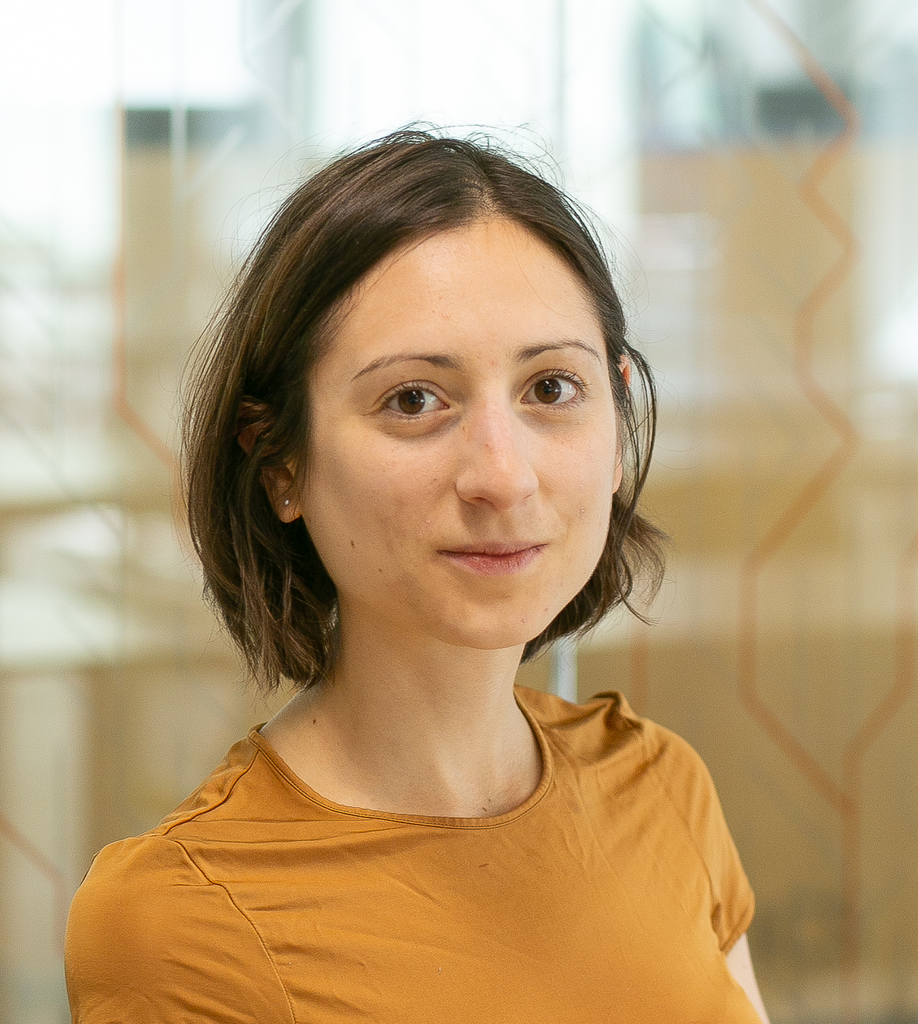

## Reports from events and conferences

**BayesComp 2025 @NUS, Singapore**  
*by David Frazier*

The biannual BayesComp conference was successfully held from June 16 to 20 at University Town, National University of Singapore. This year’s conference marked the first time it was held in Asia, and the turnout was impressive, featuring over 250 participants from more than 25 different countries. The conference program featured over 30 invited and contributed sessions spanning a range of topics in Bayesian computation, with model misspecification and approximate Bayesian inference/computation being consistent themes present throughout the conference. In addition to the main conference, two fascinating satellite meetings were also held: “Bayesian Computation and Inference with Misspecified Models” and “Bayesian Methods for Distributional and Semiparametric Regression”.

On behalf of the local organizer, David J. Nott, and my fellow scientific co-chair, Leah South, I would like to sincerely thank the local organizers, satellite organizers, scientific committee, and the participants themselves for making this year’s conference a success. The next iteration of the conference will take place at Texas A&M in 2027.

**European Seminar on Bayesian Econometrics 2025 @University of Melbourne, Australia**  
*by Jamie Cross*

The 2025 European Seminar on Bayesian Econometrics (ESOBE) was held at the University of Melbourne from August 25 to August 28. This year’s edition was hosted in Australia for the first time, with support from the Faculty of Business and Economics and Melbourne Business School at the University of Melbourne, Monash University’s Department of Econometrics and Business Statistics, and the Economics, Finance, and Business Section of ISBA.

**Program Highlights** The seminar was held on campus at the university’s dedicated conference facility, which commanded 360-degree views over the city of Melbourne. The program featured a rich set of keynotes, invited talks, and contributed sessions.

Keynote lectures were delivered by Christiane Baumeister (University of Notre Dame) on a novel nonlinear heterogeneous agent VAR, Dimitris Korobilis (University of Glasgow) on quantile VAR modelling of oil markets, and Howard Bondell (University of Melbourne) on density ratio estimation.

Invited talks included presentations from Dan Zhu (Monash University) on a new functional approach for modelling inflation target at risk, and David Frazier (Monash University) on Generalized Bayesian Methods for Predictive Inference.

Contributed sessions by junior and established scholars showcased high-quality Bayesian papers. These spanned causal inference, time series models, generalized Bayes, micro- and macro-econometric applications, and new machine learning and other methodologies that aim to capture distributional dynamics.

A well-attended poster session featured new developments in variational inference, copula methods, clustering methods, frontier models, high-frequency time series, policy evaluation, and even F1 racing.

The meeting was complemented by two fantastic masterclasses on contemporary topics: Neural Methods for Amortised Inference, delivered by Andrew Zammit Mangion (University of Wollongong); and Advances in Bayesian Finite Mixture Modeling was taught by Bettina Grün (WU Vienna).

**Honoring Herman K. van Dijk** A special moment of this year’s ESOBE was the inaugural Herman K. van Dijk seminar, given by Dimitris Korobilis. The seminar was established in memory of Herman, who was a pioneer in Bayesian econometrics and a founding figure behind ESOBE.

**Community and Engagement** The conference fostered a highly interactive environment, bringing together established leaders and emerging scholars. Social events included the conference dinner at University House in one of its historically decorated private rooms, and an excursion to the National Gallery of Victoria, which involved both a lunch overlooking the sculpture garden and a tour of its unique Australian art collection.

**Sister Event** After the conclusion of ESOBE, many of the participants travelled to a Bayesian macro-econometrics workshop held at the University of Queensland in the city of Brisbane. This two-day event was deliberately scheduled to follow on from the seminar in Melbourne and focused on a field where Bayesian thinking has become a popular choice for practitioners.

**Conclusion** ESOBE 2025 continued the tradition of advancing Bayesian econometric research in an open and collegial setting. The program highlighted both cutting-edge methodological innovations and substantive empirical applications, reinforcing the impactful role of Bayesian methods in economics, finance, and business.

**SISBAYES 2025 Workshop @University of Padova, Italy**  
*by Antonio Canale and Raffaele Argiento*

The Department of Statistical Sciences at the University of Padova was the host for the second [SISBAYES Workshop](https://sisbayes2025.stat.unipd.it/), organized by the [Bayesian section of the Italian Statistical Society](https://sisbayes.github.io/sisbayes/). The event brought together approximately 100 researchers from Italy and abroad for two days of stimulating scientific discussion and informal exchange of ideas.

The scientific program featured two foundational lectures by Sonia Petrone and Guido Consonni, alongside keynote addresses from Serena Arima and Tommaso Rigon. Six invited sessions were dedicated to modern topics in Bayesian analysis, including: Prior Elicitation for Complex Problems, Model-based Clustering, Bayesian Methods for Ecological Applications and Beyond, Bayesian Graphical Models, Bayesian Causal Inference, and Challenging Posteriors.

Reflecting a cherished ISBA tradition, a highlight of the workshop was the vibrant session for 40 contributed posters. It commenced with a welcome aperitif beneath the department’s wisteria and extended into a moonlit evening, providing a distinctive and engaging atmosphere for discussion. The scientific committee presented awards to Matteo Gianella for developing a novel and suitable methodology for an applied problem, and to Laura Ferrini for her work on an innovative methodology accompanied by a thorough investigation of its theoretical properties. An honorable mention was awarded to Andrea Ongarato for developing an interesting methodology with promising applications.

The charming venue and welcoming atmosphere made the second SISBAYES Workshop both a delightful and productive experience for all attendees. The SISBayes board of directors is already looking forward to organizing the next event in 2027. Stay tuned!

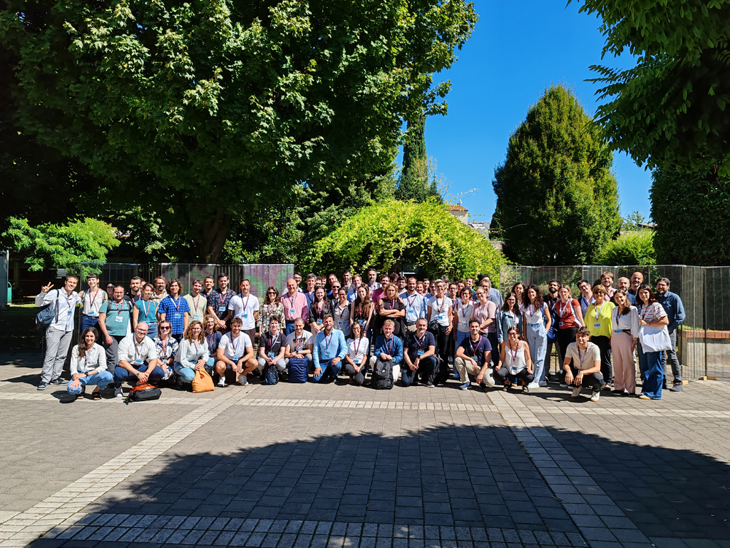

**BNP 14 @University of California, Los Angeles**  
*by Alessandra Guglielmi and Michele Guindani*

The BNP Section held its biannual international conference, BNP 14, from June 23 to 27, 2025, at UCLA in Los Angeles. The meeting drew approximately 300 participants, with particularly strong representation from the United States and Italy.

On June 22, the BNP 14 pre-conference program opened with a workshop titled ``25 Years of Dependent Dirichlet Processes (DDP)“. Introduced by MacEachern (1999–2000), the Dependent Dirichlet Process has, over the past quarter-century, inspired a rich literature on dependent random probability measures. This workshop honored that milestone by showcasing its theoretical advances, diverse applications, and future direction. A second satellite workshop on Bayesian Predictive Inference brought together researchers developing new approaches to predictive methods within Bayesian analysis, discussing both novel theory and implementation challenges.

The main scientific program of the conference featured three plenary speakers: Li Ma, Maria De Iorio, and Peter Müller, alongside five keynote lectures delivered by Federico Camerlenghi, Ismael Castillo, Stefano Favaro, Antonio Linero, and Sara Wade. The program also included 26 invited sessions (78 invited talks), 13 contributed sessions (52 contributed talks), and more than 90 poster presentations.

For the first time, keynote talks and invited sessions, in addition to contributed sessions, were held in parallel. The plenary and keynote talks provided insightful overviews of cutting-edge research. The invited and contributed sessions covered a wide range of topics, showcasing the latest developments in BNP. The poster sessions provided a lively forum for in-depth discussions. The social reception was a hit: we organized it as a private buffet light dinner in a restaurant with a bar, with ample time and space for social interaction among the participants. As one participant summarized it in their feedback, “the informal conference dinner helped socializing, and the presence of many PhD students made the atmosphere more lively and gave high hopes for the future of the community.”

The BNP 14 scientific committee received more than 110 applications for junior travel awards, and approximately $38,000 in support was awarded to recipients from the United States, Canada, South Korea, and Europe. Sponsorship spanned multiple levels: Platinum sponsors were ERC Grant 817257 and Google DeepMind, and Silver-level supporters included the University of Texas at Austin (Department of Statistics & Data Sciences), Duke University (Department of Statistical Science), UCLA’s Fielding School of Public Health (Department of Biostatistics) and College of Physical Sciences (Department of Statistics & Data Science), and Brigham Young University (Department of Statistics). One-third of the travel award funds were granted by the National Science Foundation to PhD students and postdoctoral researchers from US institutions. The meeting was co-sponsored by the Institute of Mathematical Statistics and endorsed by the ASA’s Section on Bayesian Statistical Science, alongside ISBA.

The venue for BNP 15 will be finalized and announced soon.

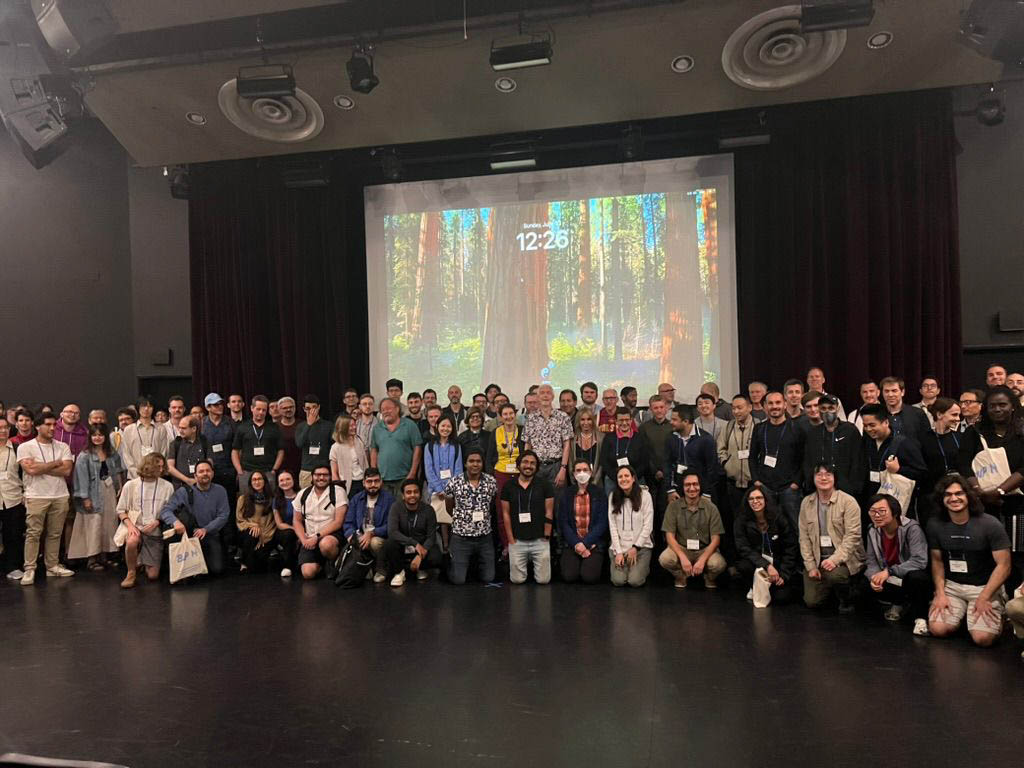

## Q&A: what do you believe think?

**What does (Bayesian) statistical fairness mean to you?**

Christos Dimitrakakis (University of Neuchatel)

There are many definitions of fairness, and each can be formalised in different ways. However, even with a given definition, whether or not something is fair can be subjective. There is also the question of what objects we are allowed to label as fair. There, I think the answer is unambiguous: it should be processes and policies rather than individual decisions or outcomes.  
I personally would like to assign a degree of fairness to decision-making policies, given a certain amount of information: the same policy can be fair or unfair depending on the information given. Given the values of all latent variables, we can perfectly characterise the fairness of a policy. Otherwise, we can merely talk about fairness only in a distributional sense. This is something that is naturally captured in a probabilistic/Bayesian framework.

Francesca Panero (Sapienza University)

*When browsing the literature on algorithmic fairness, one cannot help but notice how few Bayesian approaches are available. Why is that, one might ask? I would point to one main reason: fairness has mostly been approached from a machine learning and purely algorithmic perspective. In general, what is missing - and much needed - is a more statistical point of view, to better understand the theoretical characteristics of the constructed models. One clear contribution of Bayesian methods is the ability to investigate the impact of fair modeling choices (typically constraints on relations between sensitive variables and predictions) on model outputs and on the uncertainty of results. A field with such significant ethical, legal, and societal implications should indeed care more about these aspects.*

## Upcoming Meetings, Conferences, and Workshops

### ISBA sponsored or endorsed events

- [International Day of Women in Statistics and Data Science 2025](https://www.idwsds.org/), 14 October, online. This is a 24-hour-long free online conference. An ISBA-sponsored session features talks by Gemma Moran (Rutgers University), Cecilia Balocchi (University of Edinburgh), and Betsy Bersson (MIT).
- [ISBA World Meeting 2026](https://isba2026.github.io/), June 28 - July 3, 2026, Nagoya, Japan. Deadline for contributed talks and posters: November 21.
- [4<sup>th</sup> Bayesian Nonparametrics Networking Workshop](https://bnpnetworking2026.github.io/), 6-10 July 2026, Seoul, South Korea. This meeting, organised by the Bayesian NonParametrics (BNP) Section, has a flexible schedule and dedicated slots for early-career researchers. It aims to enhance networking within the BNP community, particularly for junior researchers.

### Other events

- [Latin American Congress of Probability and Mathematical Statistics (XVII CLAPEM)](https://clapem17.cmat.edu.uy/), 2-6 March 2026, Montevideo, Uruguay. This meeting is organised by the Latin American Society of Probability and Mathematical Statistics (SLAPEM) and the Latin American Regional Committee (LARC) of the Bernoulli Society. The deadline for submitting proposals for contributed sessions is November 10. Deadline for contributed talks and posters: December 10. Financial support is available (deadline for applications: November 30).
- [Institute of Mathematical Statistics Annual Meeting 2026](https://ims2026.github.io/IMS2026/), 6-9 July 2026, Salzburg, Austria. This meeting will feature the 2026 Wald Lecture (Tilmann Gneiting), the 2026 Blackwell Lecture, three 2026 Medallion Lectures (Ian McKeague, Bodhisattva Sen, Jelle Goeman), and the IMS Lawrence D. Brown Ph.D. Student Awards, and more than 60 invited and contributed sessions. Deadline for invited session proposals: November 15, 2025.

### And don’t forget

# ISBA ELECTION CANDIDATES 2025

Xinyi Xu

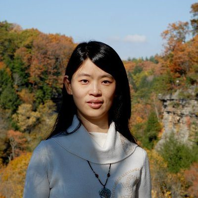

## ISBA General Elections

| Role | Name | Affiliation |
| --- | --- | --- |
| **President** | Long Nguyen | University of Michigan |
|  | Judith Rousseau | Université Paris-Dauphine |
| **Treasurer** | Leo Duan | University of Florida |
|  | Guanyu Hu | Michigan State University |
| **Board of Directors** | Sergios Agapiou | University of Cyprus |
|  | Felipe Barrientos | Florida State University |
|  | David Dahl | Brigham Young University |
|  | Beatrice Franzolini | Bocconi University |
|  | Satoshi Morita | Kyoto University |
|  | Stéphanie van der Pas | Vrije Universiteit Amsterdam |
|  | Alejandra Avalos Pacheco | JKU Linz |
|  | Susan Wei | Monash University |

## J-ISBA Section

| Role | Name | Affiliation |
| --- | --- | --- |
| **Chair-Elect** | Reetam Majumder | University of Arkansas |
|  | Francesco Gaffi | Bocconi University |
| **Program Chair** | Nicolas Bianco | KIT |
|  | Yichen Zhu | Bocconi University |
| **Secretary** | Elizabeth Louise Bersson | MIT |
|  | Jungang Zou | Columbia University |
|  | Emma Landry | UCLA |

## BNP Section

| Role | Name | Affiliation |
| --- | --- | --- |
| **Treasurer** | Filippo Ascolani | Duke University |
|  | Linxi Liu | University of Pittsburgh |
| **Chair-Elect** | Jim Griffin | University College London |
|  | Huiyan Sang | Texas A&M University |
| **Program Chair** | Antonio Linero | University of Texas at Austin |
|  | Tommaso Rigon | University of Milano-Bicocca |

## BERaP Section

[output not shown]

## EFaB Section

| Role | Name | Affiliation |
| --- | --- | --- |
| **Chair-Elect** | Roberto Casarin | Ca’ Foscari University of Venice |
|  | Liana Jacobi | University of Melbourne |
| **Treasurer** | Aubrey Poon | University of Kent |
|  | Niko Hauzenberger | University of Strathclyde |
|  | Dan Zhu | Monash University |
|  | Annika Camehl | Erasmus University Rotterdam |
|  | Maria Kalli | King’s College London |
|  | Nalan Bastürk | Vrije Universiteit Amsterdam |

## Objective Bayes Section

| Role | Name | Affiliation |
| --- | --- | --- |
| **Program Chair** | Rui Paulo | Universidade de Lisboa |
|  | Weining Shen | University of California, Irvine |
| **Treasurer** | Erica Porter | Clemson University |
|  | Xiaojin Wang | University of Connecticut |

## EnviBayes Section

| Role | Name | Affiliation |
| --- | --- | --- |
| **Treasurer** | Whitney Huang | Clemson University |
| **Chair-Elect** | David Bolin | KAUST |

### Executive Committee

**President:** Michele Guindani  
**Past President:** Aad van der Vaart  
**President Elect:** Antonio Lijoi  
**Treasurer:** Yanxun Xu  
**Executive Secretary:** Xinyi Xu

### Program Council

**Chair:** Sameer K. Deshpande  
**Vice Chair:** Yang Ni  
**Past Chair:** Sergios Agapiou

### Social Media Team

Andrew Brown, Julyan Arbel, Clara Grazian, Collin Cademartori

### Board Members

**2025–2027:**  
Sinead Williamson, Clara Grazian, Sally Paganin, David Rossell

**2024–2026:**  
Antonio Canale, Daniele Durante, Lucia Paci, Georgia Papadogeorgou

**2023–2025:**  
Tamara Broderick, Subhashis Ghosal, Claire Gormley, Matteo Ruggiero

### Editorial Board

#### Editor

*Francesco Denti*

#### Associate Editors

**Features**  
*Anton Westveld*  
**News of the World**  
*Déborah Sulem*  
**Teaching Bayes**  
*Federica Zoe Ricci*